# Przepracowani i biedni - zależność między godzinami pracy a bogactwem narodu

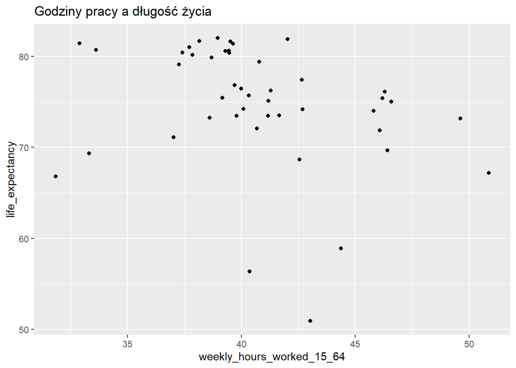

```r
ggplot(data_no_countries, aes(weekly_hours_worked_15_64, life_expectancy)) +
  geom_point() +
  ggtitle('Godziny pracy a długość życia')
```

Mocno rozsiane dane wizualnie potwierdzają umiarkowane korelacje do długości pracy. Jednak na żadnym wykresie nie widać mocnego trendu.

```r
simple_model <- lm(formula = weekly_hours_worked_15_64 ~ gdp_per_capita, data = data_no_countries)
summary(simple_model) # najlepszy R2
```

```
##
## Call:
## lm(formula = weekly_hours_worked_15_64 ~ gdp_per_capita, data = data_no_countries)
##
## Residuals:
##      Min       1Q   Median       3Q      Max
## -10.3536  -1.6381  -0.4849   1.8222   8.8073
##
## Coefficients:
##                  Estimate Std. Error t value Pr(>|t|)
## (Intercept)     4.224e+01  7.547e-01  55.965  < 2e-16 ***
## gdp_per_capita -7.049e-05  2.347e-05  -3.004  0.00444 **
## ---
## Signif. codes:  0 '***' 0.001 '**' 0.01 '*' 0.05 '.' 0.1 ' ' 1
##
## Residual standard error: 3.742 on 43 degrees of freedom
## Multiple R-squared:  0.1734, Adjusted R-squared:  0.1542
## F-statistic: 9.021 on 1 and 43 DF,  p-value: 0.004436
```

```r
simple_model_2 <- lm(formula = weekly_hours_worked_15_64 ~ life_expectancy, data = data_no_countries)
summary(simple_model_2)
```

```
##
## Call:
## lm(formula = weekly_hours_worked_15_64 ~ life_expectancy, data = data_no_countries)
##
## Residuals:
##      Min       1Q   Median       3Q      Max
## -10.2415  -1.7948  -0.2722   0.9156   8.8370
##
## Coefficients:
##                 Estimate Std. Error t value Pr(>|t|)
## (Intercept)     53.62019    6.58572   8.142 2.99e-10 ***
## life_expectancy -0.17268    0.08773  -1.968   0.0555 .
## ---
## Signif. codes:  0 '***' 0.001 '**' 0.01 '*' 0.05 '.' 0.1 ' ' 1
##
## Residual standard error: 3.942 on 43 degrees of freedom
## Multiple R-squared:  0.08265,    Adjusted R-squared:  0.06131
## F-statistic: 3.874 on 1 and 43 DF,  p-value: 0.05551
```

```r
simple_model_3 <- lm(formula = weekly_hours_worked_15_64 ~ gdp_per_capita_ppp, data = data_no_countries)
summary(simple_model_3)
```

```
##
## Call:
## lm(formula = weekly_hours_worked_15_64 ~ gdp_per_capita_ppp,
##     data = data_no_countries)
##
## Residuals:
##      Min       1Q   Median       3Q      Max
## -10.8042  -1.4281  -0.4332   2.3619   8.7124
##
## Coefficients:
##                      Estimate Std. Error t value Pr(>|t|)
## (Intercept)         4.284e+01  9.622e-01  44.526  < 2e-16 ***
## gdp_per_capita_ppp -9.158e-05  3.341e-05  -2.741  0.00888 **
## ---
## Signif. codes:  0 '***' 0.001 '**' 0.01 '*' 0.05 '.' 0.1 ' ' 1
##
## Residual standard error: 3.798 on 43 degrees of freedom
## Multiple R-squared:  0.1488, Adjusted R-squared:  0.129
## F-statistic: 7.515 on 1 and 43 DF,  p-value: 0.008877
```

```r
complex_model <- lm(formula = weekly_hours_worked_15_64 ~ gdp_per_capita_ppp + enrollment_tetriary + income_inequality, data = data_no_countries)
summary(complex_model)
```

```
##
## Call:
## lm(formula = weekly_hours_worked_15_64 ~ gdp_per_capita_ppp +
##     enrollment_tetriary + income_inequality, data = data_no_countries)
##
## Residuals:
##      Min       1Q   Median       3Q      Max
## -10.5852  -1.4800  -0.3204   1.6029   9.0012
##
## Coefficients:
##                       Estimate Std. Error t value Pr(>|t|)
## (Intercept)          4.137e+01  4.048e+00  10.219 7.73e-13 ***
## gdp_per_capita_ppp  -7.959e-05  3.998e-05  -1.991   0.0532 .
## enrollment_tetriary -3.674e-03  2.826e-02  -0.130   0.8972
## income_inequality    3.897e-02  8.067e-02   0.483   0.6316
## ---
## Signif. codes:  0 '***' 0.001 '**' 0.01 '*' 0.05 '.' 0.1 ' ' 1
##
## Residual standard error: 3.873 on 41 degrees of freedom
## Multiple R-squared:  0.1558, Adjusted R-squared:  0.09403
## F-statistic: 2.522 on 3 and 41 DF,  p-value: 0.07105
```

Żaden model nie ma wysokiego R-squared, co znaczy, że wariancja PKB nie tłumaczy wariancji working hours jednakże lepiej się spisuje niż model złożony z 3 parametrów (PKB PPP, uczęszczania na uczelnie i Giniego). Do tego w prostym modelu nasza jedyna zmienna ma niższe p-value.

# Wniosek

Moje dane w umiarkowanym stopniu potwierdziły korelację bogactwa kraju i ilości godzin przepracowanych (bogatszy kraj = mniej godzin). Jednak żadne dane nie mogły w wystarczającym stopniu wytłumaczyć wariancji

# Zastrzeżenia

Użyłem 45 krajów, bo nie dla wszystkich mogłem znaleźć dane, szczególnie enrollment_in_tetriary_education i working_hours. Dla 2010 roku było ich 46, ale wyniki dla Korei wyglądały na bezsensowne (13 godzin pracy w tyg), więc postanowiłem je usunąć. #notinvestmentadvice